# Evidencia Semana 2

Author

Camilo Andres Bohorquez Montenegro

Published

September 30, 2024

# 1 Introducción

# 2 Medidas de tendencia central

Para ilustrar el uso de las funciones se utilizará una base de datos llamada **medidas del cuerpo**, esta base de datos cuenta con 6 variables registradas a un grupo de 36 estudiantes de la universidad. Las variables son:

1. `edad` del estudiante (años),
2. `peso` del estudiante (kilogramos),
3. `altura` del estudiante (centímetros),
4. `sexo` del estudiante (Hombre, Mujer),
5. `muneca`: perímetro de la muñeca derecha (centímetros),
6. `biceps`: perímetro del biceps derecho (centímetros).

```r
url <- 'https://raw.githubusercontent.com/fhernanb/datos/master/medidas_cuerpo'
datos <- read.table(file=url, header=T)
head(datos)  # Para ver el encabezado de la base de datos
```

```
  edad peso altura   sexo muneca biceps
1   43 87.3  188.0 Hombre   12.2   35.8
2   65 80.0  174.0 Hombre   12.0   35.0
3   45 82.3  176.5 Hombre   11.2   38.5
4   37 73.6  180.3 Hombre   11.2   32.2
5   55 74.1  167.6 Hombre   11.8   32.9
6   33 85.9  188.0 Hombre   12.4   38.5
```

## 2.1 Media

Para calcular la media de una variable cuantitativa se usa la función `mean`. Los argumentos básicos de la función `mean` son dos y se muestran a continuación.

```r
# mean(x,na.rm = FALSE)
```

En el parámetro `x` se indica la variable de interés para la cual se quiere calcular la media, el parámetro `na.rm` es un valor lógico que en caso de ser `TRUE`, significa que se deben remover las observaciones con `NA`, el valor por defecto para este parámetro es `FALSE`.

Ejemplo:

Suponga que queremos obtener la altura media del grupo de estudiantes.

Para encontrar la media general se usa la función `mean` sobre el vector númerico `datos$altura`.

```r
mean(x = datos$altura)
```

```
[1] 171.5556
```

Del anterior resultado podemos decir que la estatura media o promedio de los estudiantes es 171.5555556 centímetros.

### 2.1.1 Media aritmética, media, promedio

Graficas de lineas

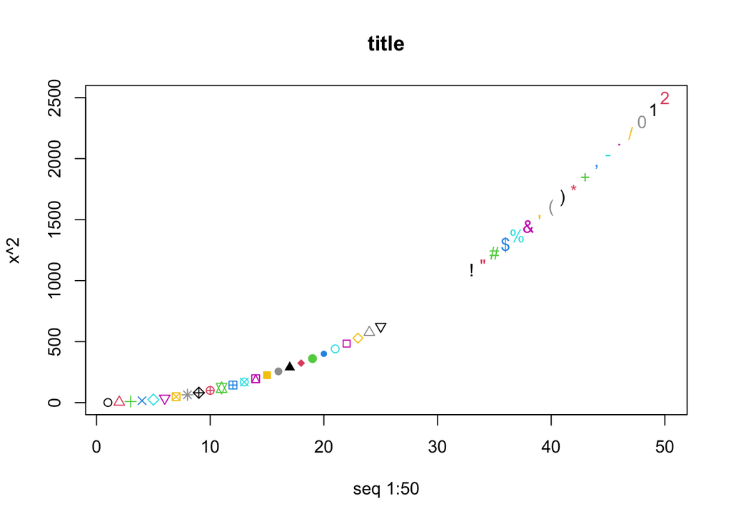

```r
x = 1:50
y = x^2
plot(x,y, main = "title",
     xlab = "seq 1:50",ylab = "x^2",
     col = 1:50,pch = 1:50)
```

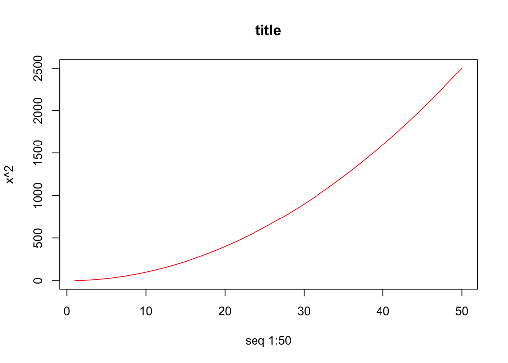

```r
x = 1:50
y = x^2
plot(x,y, main = "title",
     xlab = "seq 1:50",ylab = "x^2",
     col = "red", type = "l")
```

Ejemplo 2:

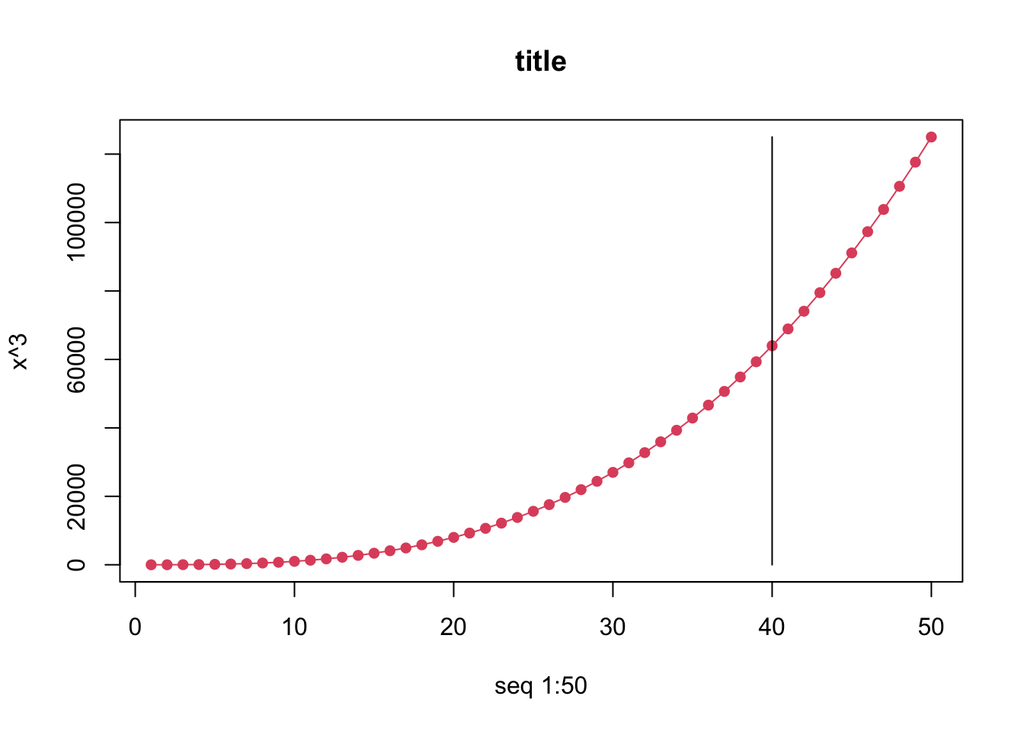

```r
x = 1:50
y = x^3
plot(x,y, main = "title",
     xlab = "seq 1:50",ylab = "x^3",
     col = 10,pch = 16, type = "o")
# vertical line
x_line = c(40,40)
y_line = c(min(y),max(y))
lines(x = x_line, y = y_line, col=1,lwd = 1, type= "l")
```

Grafico de Cajas

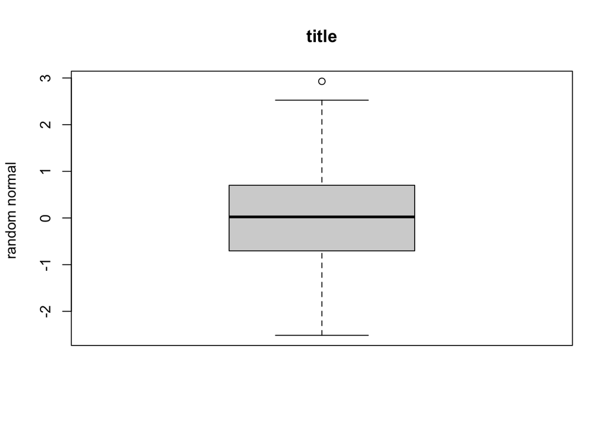

```r
set.seed(132)
x <- rnorm(500)
boxplot(x, main = "title",ylab = "random normal ")
```

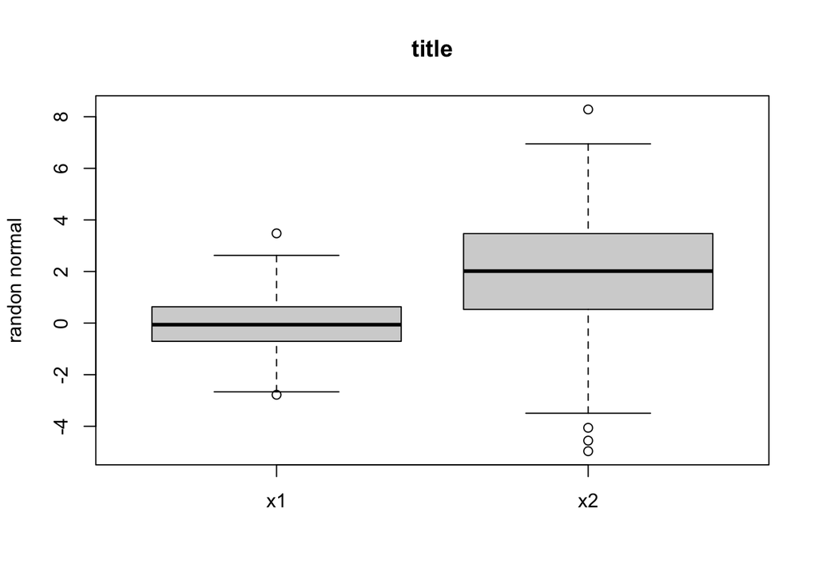

```r
set.seed(897564563)
x1 <- rnorm(500)
x2 <- rnorm(500, mean = 2,sd= 2)
data= cbind(x1,x2)
boxplot(data,main ="title",ylab="randon normal")
```

```r
quantile(data[,1])
```

```
         0%         25%         50%         75%        100%
-2.77853104 -0.70458576 -0.06099977  0.63065958  3.47836713
```

```r
quantile(data[,2])
```

```
        0%        25%        50%        75%       100%
-4.9659941  0.5312242  2.0151032  3.4627141  8.2825594
```